# ProblemSet1

# Problem Set 1

Week I: Introduction to Computational Biology / Molecular Biology

## Question 1

**Read in the table of human chromosome sizes (hg38_sizes.txt), and plot a barplot of their sizes in Mb (megabases).** (1 mark)

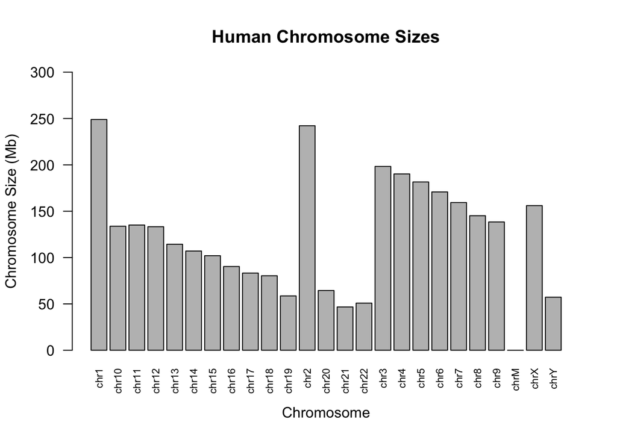

```r
hg38_sizes <- read.table("../data/problem-set-1/hg38_sizes.txt", quote="\"", comment.char="")
barplot(V2/1000000 ~ V1,
        data= hg38_sizes,
        las = 2,
        cex.names = 0.7,
        main = "Human Chromosome Sizes",
        xlab = "Chromosome",
        ylab = "Chromosome Size (Mb)",
        ylim= c(0,300))
```

Make sure you can read all of the chromosome names.

## Question 2

The file orf_coding.fasta contains the open reading frames in the yeast genome. Take the time to investigate what an open reading frame is

**Plot a histogram of the size of the all of the orfs in the yeast genome and calculate the mean and median ORF size.** (2 marks)

```r
library(Biostrings)
getwd() #get working directory #which folder is it accessing?
```

```
## [1] "/Users/Hardisk_WeiFeng/Comp Bio/problem-sets"
```

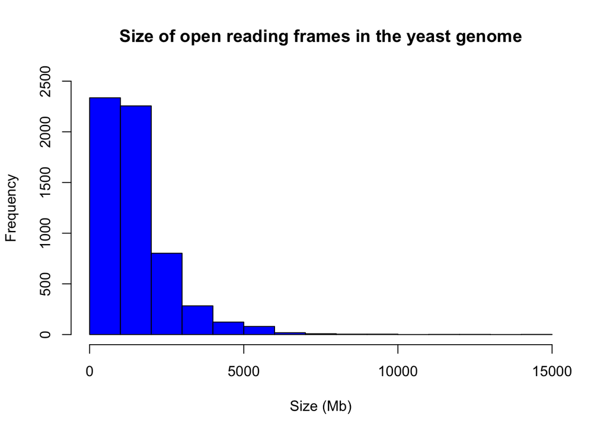

```r
setwd("../data/problem-set-1") #set working directory #access this folder
yeast_orf= readDNAStringSet("orf_coding.fasta")

hist(nchar(yeast_orf),
     main = "Size of open reading frames in the yeast genome",
     col = "blue",
     ylim= c(0,2500),
     xlab= "Size (Mb)")
```

```r
#mean ORF size
mean(nchar(yeast_orf))
```

```
## [1] 1485.306
```

```r
#median ORF size
median(nchar(yeast_orf))
```

```
## [1] 1218
```

**Do you think mean or median is a better way of representing the average ORF size (and why)?** (1 mark)

median is a better way of representing the average ORF size. this is because, as seen from the histogram, the distribution of ORF sizes is right-skewed, thus extremely large but rare ORF sizes will significantly affect the mean, but not the median.

### Question 3

**Calculate the percentage of Gs and Cs for each ORF (this is called GC content) . How many ORFs have GC content greater than 50%?** (2 marks)

```r
yeast_orf_ATGC<- letterFrequency(yeast_orf, c("A", "T", "G", "C"))

yeast_orf_GCcontent<- (yeast_orf_ATGC[,"G"]+ yeast_orf_ATGC[,"C"])/ (yeast_orf_ATGC[,"A"] + yeast_orf_ATGC[,"T"]+ yeast_orf_ATGC[,"G"]+ yeast_orf_ATGC[,"C"])*100

sum(yeast_orf_GCcontent>50)
```

```
## [1] 78
```

78ORFs have GC content greater than 50%

### Question 4

**So all of these DNA sequences encode for potential proteins, transcribe all of these DNA sequences into RNA.** (1 marks)

```r
RNAStringSet(yeast_orf) #transcribe DNA sequences into RNA
```

```
## RNAStringSet object of length 5917:
##        width seq                                            names
##    [1]  3483 AUGGUACUGACGAUUUAUCCUG...UCUAUAUAUGAAUCUACAUAA YAL001C TFC3 SGDI...
##    [2]  3825 AUGGAGCAAAAUGGCCUUGACC...UCUAACCCAAAAAUAGUAUAA YAL002W VPS8 SGDI...
##    [3]   621 AUGGCAUCCACCGAUUUCUCCA...GCUGCUAUGCAAAAAUUAUAA YAL003W EFB1 SGDI...
##    [4]  1929 AUGUCAAAAGCUGUCGGUAUUG...ACCGUUGAAGAAGUUGAUUAA YAL005C SSA1 SGDI...
##    [5]   648 AUGAUCAAAUCUACAAUUGCUC...CGUCAAAAAAAUUACGUUUAA YAL007C ERP2 SGDI...
##    ...   ... ...
## [5913]   810 AUGACACAUUUAGAAAGAAGUA...UUCUACUGAUGAGGAGUCUAA Q0275 COX3 SGDID:...
## [5914]  1272 AUGCCACAAUUUGGUAUAUUAU...UACAUAAAUAGACGCAUAUAA R0010W FLP1 SGDID...
## [5915]  1122 AUGAAUGGCGAGAGACUGCUUG...GAGCGAAAGGUGGAUGGGUAG R0020C REP1 SGDID...
## [5916]   546 AUGCCUUAUAAAACAGCUAUAG...AGUAUAUUUGAACCUGUAUAA R0030W RAF1 SGDID...
## [5917]   891 AUGGACGACAUUGAAACAGCCA...CGUAAUACUUCUAGGGUAUGA R0040C REP2 SGDID...
```

**So all of these DNA sequences encode for potential proteins, translate all of these DNA sequences into Protein.** (1 mark)

```r
translate(yeast_orf) #translate DNA sequences into protein
```

```
## AAStringSet object of length 5917:
##        width seq                                            names
##    [1]  1161 MVLTIYPDELVQIVSDKIASNK...TTDFDGYWVNHNWYSIYEST* YAL001C TFC3 SGDI...
##    [2]  1275 MEQNGLDHDSRSSIDTTINDTQ...QKPDEYSCLICQTESNPKIV* YAL002W VPS8 SGDI...
##    [3]   207 MASTDFSKIETLKQLNASLADK...SIEEDEDHVQSTDIAAMQKL* YAL003W EFB1 SGDI...
##    [4]   643 MSKAVGIDLGTTYSCVAHFAND...FPGGAPPAPEAEGPTVEEVD* YAL005C SSA1 SGDI...
##    [5]   216 MIKSTIALPSFFIVLILALVNS...SIAQVLLIQFLFTGRQKNYV* YAL007C ERP2 SGDI...
##    ...   ... ...
## [5913]   270 MTHLERSRHQQHPFHMVMPSP*...LHVLDVI*LFLYVVFY**GV* Q0275 COX3 SGDID:...
## [5914]   424 MPQFGILCKTPPKVLVRQFVER...NGIISQEVLDYLSSYINRRI* R0010W FLP1 SGDID...
## [5915]   374 MNGERLLACIKQCIMQHFQPMV...KPVDVEVEFRCKFKERKVDG* R0020C REP1 SGDID...
## [5916]   182 MPYKTAIDCIEELATQCFLSKL...NFEHPNLGVFPETDSIFEPV* R0030W RAF1 SGDID...
## [5917]   297 MDDIETAKNLTVKARTAYSVWD...KKRRVATRVRGRKSRNTSRV* R0040C REP2 SGDID...
```

### Question 5

**Plot the distribution of amino acid usage of all yeast ORFs … (i.e how many times is each individual amino acid encoded - you do not need to include STOP codons).** (2 marks)

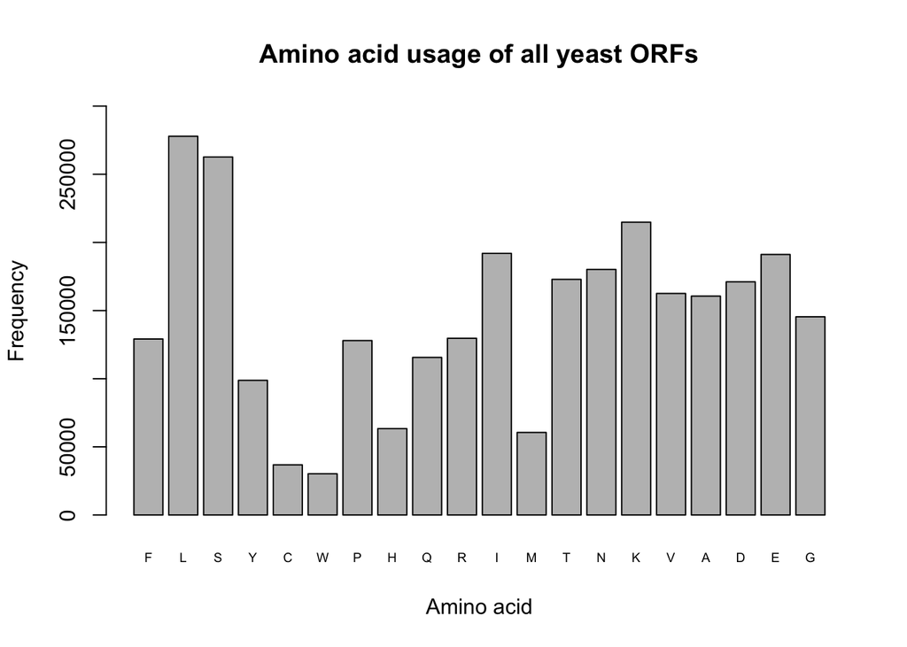

```r
yeast_aa_strings <- translate(yeast_orf) #store amino acid sequences of proteins

aa_list<- c("F","L","S","Y","C","W","P","H","Q","R","I","M","T","N","K","V","A","D","E","G") #store list of amino acids
aa_count_prot <- letterFrequency(yeast_aa_strings, aa_list) #create matrix to store the amino acid count of each protein
aa_count_prot<- as.data.frame(aa_count_prot) #convert matrix into dataframe

aa_count_total= c()
for( i in 1:ncol(aa_count_prot) ){
      aa_count_total= c(aa_count_total,sum(aa_count_prot[,i]))
} #find the total number of each amino acid

barplot(aa_count_total,
        names.arg = aa_list,
        main= "Amino acid usage of all yeast ORFs",
        xlab= "Amino acid",
        ylab= "Frequency",
        ylim= c(0,300000),
        cex.names = 0.6)
```